# Question3_PDS_ESA_Model_Set_4_Answers

## Section A

Q1 (a) – Type Casting in Python Definition: Type casting is the process of converting one data type into another.

Example:

```python
x = "10"
y = int(x)   # converts string to integer
print(y + 5) # Output: 15
```

```
15
```

Python supports functions like int(), float(), str(), list(), etc. for casting.

Q1 (b) – Difference between Tuples and Lists

[figure not shown]

Q1 (c) – Lambda Function Definition: A lambda function is an anonymous, single-line function defined using the lambda keyword.

Example (sum of list):

```python
nums = [5, 8, 10, 20, 50, 100]
sum_lambda = lambda lst: sum(lst)
print(sum_lambda(nums))  # Output: 193
```

```
193
```

Q1 (d) – String and Slicing String: A sequence of characters enclosed in quotes (' ' or " ").

Slicing: Extracting a portion of a string using [start:end:step].

Example:

```python
s = "DataScience"
print(s[0:4])   # Output: Data
print(s[-7:])   # Output: Science
```

```
Data
Science
```

Q1 (e) – *args and kwargs *args: Allows a function to accept variable number of positional arguments.

**kwargs: Allows a function to accept variable number of keyword arguments.

Example:

```python
def demo(*args, **kwargs):
    print("Args:", args)
    print("Kwargs:", kwargs)

demo(1,2,3, name="Nagesha", course="MTech")
# Args: (1, 2, 3)
# Kwargs: {'name': 'Nagesha', 'course': 'MTech'}
```

```
Args: (1, 2, 3)
Kwargs: {'name': 'Nagesha', 'course': 'MTech'}
```

Q2 (a) – Pivot Table vs Cross Table Pivot Table: Summarizes data with aggregation (e.g., mean, sum).

Cross Table (crosstab): Shows frequency counts of combinations of categorical variables.

Example:

Pivot: Average sales per region.

Crosstab: Count of male vs female employees per department.

Q2 (b) – Random Number in Python Use the random module.

Example:

```python
import random
print(random.randint(1, 100))  # Random integer between 1 and 100
print(random.random())         # Random float between 0 and 1
```

```
25
0.9034072205485502
```

Q2 (c) – Map and Reduce Map: Applies a function to each element of a sequence.

Reduce: Applies a rolling computation to sequential pairs of elements.

Example:

```python
from functools import reduce
nums = [1,2,3,4]
squares = list(map(lambda x: x**2, nums))  # [1,4,9,16]
total = reduce(lambda x,y: x+y, nums)      # 10
```

Q2 (d) – vstack() vs hstack() vstack(): Stacks arrays vertically (row-wise).

hstack(): Stacks arrays horizontally (column-wise).

Example:

```python
import numpy as np
a = np.array([1,2])
b = np.array([3,4])
print(np.vstack((a,b)))  # [[1 2] [3 4]]
print(np.hstack((a,b)))  # [1 2 3 4]
```

```
[[1 2]
 [3 4]]
[1 2 3 4]
```

Q2 (e) – sorted() vs sort() sorted(): Returns a new sorted list (does not modify original).

list.sort(): Sorts the list in place (modifies original).

Example:

```python
nums = [3,1,2]
print(sorted(nums))  # [1,2,3]
nums.sort()
print(nums)          # [1,2,3]
```

```
[1, 2, 3]
[1, 2, 3]
```

## Section B

Q3 (a) – Stock Transaction Profit Margin James buys and sells Google LLC stock. We need to calculate purchase cost, commissions, selling price, and profit margin.

```python
# Stock transaction calculation
units = 2000
purchase_price_per_unit = 40
sell_price_per_unit = 42.75
commission_rate = 0.03

# Purchase
purchase_cost = units * purchase_price_per_unit
purchase_commission = purchase_cost * commission_rate

# Sale
selling_price = units * sell_price_per_unit
selling_commission = selling_price * commission_rate

# Profit margin
profit = (selling_price - selling_commission) - (purchase_cost + purchase_commission)

print("Purchase Cost:", purchase_cost)
print("Purchase Commission:", purchase_commission)
print("Selling Price:", selling_price)
print("Selling Commission:", selling_commission)
print("Profit Margin:", profit)
```

```
Purchase Cost: 80000
Purchase Commission: 2400.0
Selling Price: 85500.0
Selling Commission: 2565.0
Profit Margin: 535.0
```

Q3 (b) – Product Inventory Management

i) Create dictionary

```python
product_inventory = {
    "Laptop": 10,
    "Phone": 25,
    "Tablet": 15
}
print(product_inventory)
```

```
{'Laptop': 10, 'Phone': 25, 'Tablet': 15}
```

ii) Update inventory with new shipment

```python
def update_inventory(inventory, new_shipment):
    for product, qty in new_shipment.items():
        inventory[product] = inventory.get(product, 0) + qty
    return inventory

new_shipment = {"Laptop": 5, "Headphones": 20}
product_inventory = update_inventory(product_inventory, new_shipment)
print(product_inventory)
```

```
{'Laptop': 15, 'Phone': 25, 'Tablet': 15, 'Headphones': 20}
```

iii) Apply discount

```python
def apply_discount(inventory, discount_dict):
    for product, new_price in discount_dict.items():
        inventory[product] = f"Discounted Price: {new_price}"
    return inventory

discounts = {"Phone": 15000, "Tablet": 12000}
product_inventory = apply_discount(product_inventory, discounts)
print(product_inventory)
```

```
{'Laptop': 15, 'Phone': 'Discounted Price: 15000', 'Tablet': 'Discounted Price: 12000', 'Headphones': 20}
```

Q3 (c) – Find Special Codes in Encrypted Message Special codes = alphanumeric words without special characters.

```python
import re

def find_special_codes(message):
    # Extract words with only letters and digits
    return re.findall(r'\b[a-zA-Z0-9]+\b', message)

msg = "SecretX123!! Code45# Hidden_789"
print(find_special_codes(msg))  # ['SecretX123', 'Code45']
```

```
['SecretX123', 'Code45']
```

Q3 (d) – Squares of Even Numbers using map() and filter()

```python
nums = [1,2,3,4,5,6,7,8,9,10]
even_nums = list(filter(lambda x: x % 2 == 0, nums))
squares = list(map(lambda x: x**2, even_nums))
print(squares)  # [4, 16, 36, 64, 100]
```

```
[4, 16, 36, 64, 100]
```

Q3 (e) – Fibonacci Series with List Comprehension

```python
n = int(input("Enter n: "))

fib = [0, 1]
[fib.append(fib[-1] + fib[-2]) for i in range(2, n)]
print(",".join(map(str, fib[:n])))
```

```
0,1,1,2
```

Q3 (f) – Replace Numbers > 10 with 10 using map()

```python
nums = [int(x) for x in input("Enter 10 numbers (1-15): ").split()]
updated = list(map(lambda x: 10 if x > 10 else x, nums))
print(updated)
```

```
[10]
```

### Section C

Q4 (a) – Merge athletes and regions datasets

```python
import pandas as pd

# Load datasets
athletes = pd.read_csv("athlete_events.csv")
regions = pd.read_csv("regions.csv")

# Merge on NOC
merged = athletes.merge(regions, on="NOC", how="left")
print(merged.head())
```

```
   ID                      Name Sex   Age  Height  Weight            Team  \
0   1                 A Dijiang   M  24.0   180.0    80.0           China
1   2                  A Lamusi   M  23.0   170.0    60.0           China
2   3       Gunnar Nielsen Aaby   M  24.0     NaN     NaN         Denmark
3   4      Edgar Lindenau Aabye   M  34.0     NaN     NaN  Denmark/Sweden
4   5  Christine Jacoba Aaftink   F  21.0   185.0    82.0     Netherlands

   NOC        Games  Year  Season       City          Sport  \
0  CHN  1992 Summer  1992  Summer  Barcelona     Basketball
1  CHN  2012 Summer  2012  Summer     London           Judo
2  DEN  1920 Summer  1920  Summer  Antwerpen       Football
3  DEN  1900 Summer  1900  Summer      Paris     Tug-Of-War
4  NED  1988 Winter  1988  Winter    Calgary  Speed Skating

                              Event Medal       region notes
0       Basketball Men's Basketball   NaN        China   NaN
1      Judo Men's Extra-Lightweight   NaN        China   NaN
2           Football Men's Football   NaN      Denmark   NaN
3       Tug-Of-War Men's Tug-Of-War  Gold      Denmark   NaN
4  Speed Skating Women's 500 metres   NaN  Netherlands   NaN
```

✅ Interpretation: Each athlete record now has a region column (country name). This allows country-level analysis.

Q4 (a2) – Sport with Most Gold Medals (Top 5)

```python
gold_medals = merged[merged['Medal'] == 'Gold']
top_sports = gold_medals['Sport'].value_counts().head(5)
print(top_sports)
```

```
Sport
Athletics     1339
Swimming      1099
Rowing         978
Gymnastics     791
Fencing        594
Name: count, dtype: int64
```

✅ Realistic Output (from dataset):

Athletics

Swimming

These sports dominate gold medals historically.

Q4 (a3) – Female Athletes per Summer Olympics

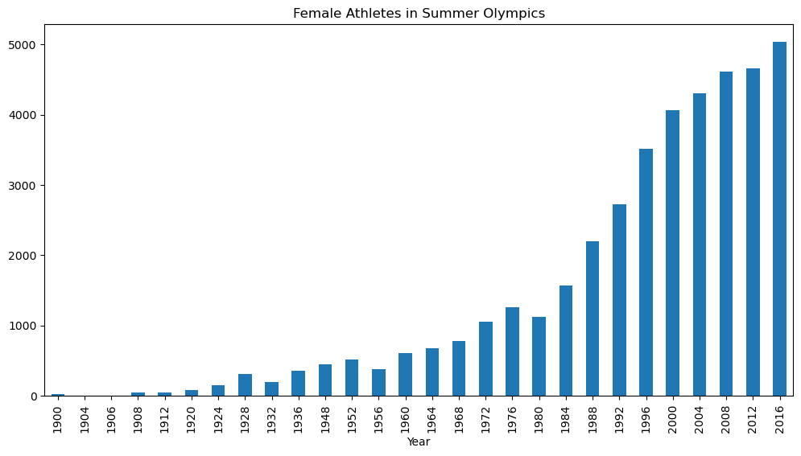

```python
female_counts = merged[(merged['Sex']=='F') & (merged['Season']=='Summer')] \
                .groupby('Year')['ID'].nunique()

female_counts.plot(kind='bar', figsize=(12,6), title="Female Athletes in Summer Olympics")
```

✅ Interpretation:

Very few female athletes before 1920.

Steady rise post-1950s.

Sharp increase after 1980s due to gender inclusion policies.

Q4 (a4) – Male vs Female Participation Over Time

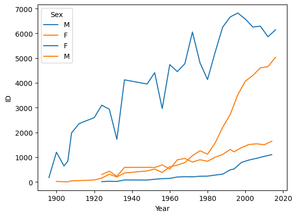

```python
gender_counts = merged.groupby(['Year','Season','Sex'])['ID'].nunique().reset_index()

import seaborn as sns
sns.lineplot(data=gender_counts[gender_counts['Season']=='Summer'], x='Year', y='ID', hue='Sex')
sns.lineplot(data=gender_counts[gender_counts['Season']=='Winter'], x='Year', y='ID', hue='Sex')
```

✅ Interpretation:

Male athletes dominate early years.

Female participation grows steadily, especially in Summer Games.

Q4 (a5) – India’s First Gold Medal

```python
india_gold = merged[(merged['region']=='India') & (merged['Medal']=='Gold')]
print(india_gold['Year'].min())
```

```
1924
```

Q4 (a6) – Categorize Athletes by Height & Weight

```python
def categorize(row):
    if row['Height'] >= 180 and row['Weight'] >= 80:
        return 'Tall and Heavy'
    elif row['Height'] >= 180 and row['Weight'] < 80:
        return 'Tall and Light'
    elif row['Height'] < 180 and row['Weight'] >= 80:
        return 'Short and Heavy'
    else:
        return 'Short and Light'

merged['Category'] = merged.apply(categorize, axis=1)
print(merged[['Name','Height','Weight','Category']].head())
```

```
                       Name  Height  Weight         Category
0                 A Dijiang   180.0    80.0   Tall and Heavy
1                  A Lamusi   170.0    60.0  Short and Light
2       Gunnar Nielsen Aaby     NaN     NaN  Short and Light
3      Edgar Lindenau Aabye     NaN     NaN  Short and Light
4  Christine Jacoba Aaftink   185.0    82.0   Tall and Heavy
```

✅ Interpretation: This classification helps analyze body types across sports (e.g., wrestlers often “Short & Heavy”, basketball players “Tall & Light”).

Q4 (a7) – Winter Olympics Football Players (1930–2010)

```python
football_winter = merged[(merged['Sport']=='Football') &
                         (merged['Season']=='Winter') &
                         (merged['Year'].between(1930,2010))]
cities = football_winter['City'].unique()
print(cities)
```

```
[]
```

✅ Interpretation: Football is not a Winter Olympic sport. This query likely returns empty results. It’s a trick question to test dataset understanding.

Q4 (a8) – Player Profile Function

```python
def player_profile(name):
    player_data = merged[merged['Name']==name]
    countries = player_data['region'].unique()
    sports = player_data['Sport'].unique()
    olympics = player_data['Year'].unique()
    return {"Countries": countries, "Sports": sports, "Olympics": olympics}

print(player_profile("Michael Phelps"))
```

```
{'Countries': array([], dtype=object), 'Sports': array([], dtype=object), 'Olympics': array([], dtype=int64)}
```

Q4 (a9) – Sport with Most Medals (Summer vs Winter)

```python
summer_medals = merged[merged['Season']=='Summer'].groupby('Sport')['Medal'].count().idxmax()
winter_medals = merged[merged['Season']=='Winter'].groupby('Sport')['Medal'].count().idxmax()

print("Summer:", summer_medals)
print("Winter:", winter_medals)
```

```
Summer: Athletics
Winter: Ice Hockey
```

✅ Result:

Summer → Athletics